# GDP Growth Nowcasting Workshop

Trinidad and Tobago · Monday · Welcome

Diego A. Guerrero

GDP Growth Nowcasting Workshop · Trinidad and Tobago

## Why we are here

- GDP for a quarter is published **months** after the quarter ends
- Meanwhile, decisions on monetary, fiscal and energy policy cannot wait
- A **nowcast** uses timely data to estimate GDP growth **before** it is published

In three days (after Friday’s installation clinic) you will build one, end to end, for Trinidad and Tobago, in Python and R, with the same code the IDB team uses.

## What you will leave with

- A working Python environment (`nwcst`) and a geospatial one (`geo`)
- Notebooks that **download** CBTT, international, Google Trends and satellite data
- A **build** that turns ~50 sources into one monthly panel of ~640 series
- Hands-on experience with regularized, tree, neural-net and time-series models
- A **nowcasting tool** that compares them across vintages
- The habit of asking: *does this beat a naive benchmark?*

## Agenda

|  | Morning | Afternoon |
| --- | --- | --- |
| **Friday** | Installation clinic (in person) |  |
| **Monday** | Welcome · Python fundamentals · R fundamentals | Data: scraping · nighttime lights · Google Trends · the build |
| **Tuesday** | Methodology · Block 1 regularization · Block 2 trees | Block 3 LSTM · Block 4 time-series models (R) |
| **Wednesday** | Variable selection · the nowcast tool | Results · using the tool · wrap-up |

Tuesday’s blocks: theory, then an activity in Python **and** R.

## How the sessions work

- Short slides, then a **notebook** you run yourself
- Every notebook has a worked version in `sols/`
- One file to edit: `activity/config.py`
- All materials: the course page and `README.md`

## Trinidad and Tobago in the data

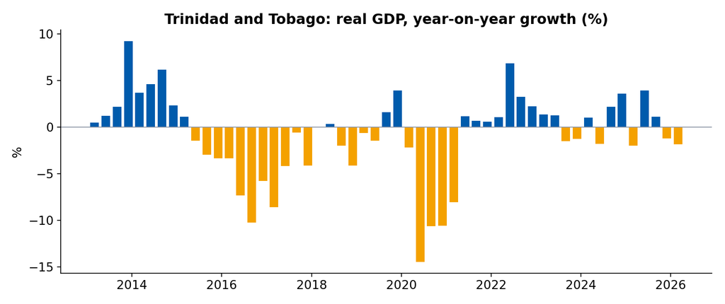

Energy busts (2015–17), COVID (2020), and a hesitant recovery since. The last published quarter is 2026Q1: **what happened since?** That is the question.

## Facilitators

- **Jose L. Saboin**
- **Diego A. Guerrero**
- **Angelo Mazzocca**